# Reproducible Research Peer Assignment 1

Student: Huertas

Thursday, February 12, 2015

## Introduction

This entire assignment consists in making a report with a **single R markdown** document that can be processed by **knitr** and be transformed into an HTML file. It contains a text explanaining the report, the code and the output of statistical processes. This is the basis of **Reproducible Research**.

### Data

It is now possible to collect a large amount of data about personal movement using activity monitoring devices such as a [Fitbit](http://www.fitbit.com), [Nike Fuelband](http://www.nike.com/us/en_us/c/nikeplus-fuelband), or [Jawbone Up](https://jawbone.com/up). These type of devices are part of the “quantified self” movement – a group of enthusiasts who take measurements about themselves regularly to improve their health, to find patterns in their behavior, or because they are tech geeks. But these data remain under-utilized both because the raw data are hard to obtain and there is a lack of statistical methods and software for processing and interpreting the data.

This **report** makes use of data from a personal activity monitoring device. This device collects data at 5 minute intervals through out the day. The data consists of two months of data from an anonymous individual collected during the months of October and November, 2012 and include the number of steps taken in 5 minute intervals each day.

The data for this assignment can be downloaded from the course web site:

- Dataset: [Activity monitoring data](https://d396qusza40orc.cloudfront.net/repdata%2Fdata%2Factivity.zip) [52K]. The zip file contains the `activity.csv` file which is a comma-separated-value (CSV) file and there are a total of 17,568 observations in this dataset.

The variables included in this dataset are:

- **steps**: Number of steps taking in a 5-minute interval (missing values are coded as `NA`)
- **date**: The date on which the measurement was taken in YYYY-MM-DD format
- **interval**: Identifier for the 5-minute interval in which measurement was taken

After decompressing the zip file into a suitable folder it is necessary to put the data into R environment and to process it.

### Loading, visualization and preprocessing the data

1. Loading and visualization of the data (i.e. `read.csv()`)

```r
    activityData <- read.csv("./data/activity.csv") #read the data into a var
    str(activityData) #show the structure of the data
```

```
## 'data.frame':    17568 obs. of  3 variables:
##  $ steps   : int  NA NA NA NA NA NA NA NA NA NA ...
##  $ date    : Factor w/ 61 levels "2012-10-01","2012-10-02",..: 1 1 1 1 1 1 1 1 1 1 ...
##  $ interval: int  0 5 10 15 20 25 30 35 40 45 ...
```

```r
    head(activityData)  #show first rows
```

```
##   steps       date interval
## 1    NA 2012-10-01        0
## 2    NA 2012-10-01        5
## 3    NA 2012-10-01       10
## 4    NA 2012-10-01       15
## 5    NA 2012-10-01       20
## 6    NA 2012-10-01       25
```

```r
    tail(activityData)  #show last rows
```

```
##       steps       date interval
## 17563    NA 2012-11-30     2330
## 17564    NA 2012-11-30     2335
## 17565    NA 2012-11-30     2340
## 17566    NA 2012-11-30     2345
## 17567    NA 2012-11-30     2350
## 17568    NA 2012-11-30     2355
```

2. Process/transform the data (if necessary) into a format suitable for your analysis.

For understanding the day timetable it is better to transform the `interval` var into 24hours time format. This is achieved creating a function named `Hour_minute`:

```r
Hour_minute<- function (minutes=integer()){
  hour<-as.character(as.integer((minutes/60)))
  hour<-paste(ifelse(nchar(hour)>1,"","0"),hour,sep="")
  minu<-as.character(minutes %% 60)
  minu<-paste(ifelse(nchar(minu)>1,"","0"),minu,sep="")
  paste(hour,":",minu,sep="") }                       #returns "h:m" format.
activityData$time<-Hour_minute(activityData$interval)
```

In this case, the principal transformation of the data consists in deleting the rows with `NA` values, therefore a subset will be obtained and stored in `activityNoNA` var:

```r
   activityNoNA<-activityData[!is.na(activityData$steps),]
   str(activityNoNA)
```

```
## 'data.frame':    15264 obs. of  4 variables:
##  $ steps   : int  0 0 0 0 0 0 0 0 0 0 ...
##  $ date    : Factor w/ 61 levels "2012-10-01","2012-10-02",..: 2 2 2 2 2 2 2 2 2 2 ...
##  $ interval: int  0 5 10 15 20 25 30 35 40 45 ...
##  $ time    : chr  "00:00" "00:05" "00:10" "00:15" ...
```

Notice that the new data witout NA contains **2304 rows** less than original dataset, it represents a 13.1147541 % of the data; it would be interesting to know if the **NA has a pattern** of distribution over the time along the **61 days**.

Other data transformation will be applied in every stage of data analysis.

### What is mean total number of steps taken per day?

1. Graphics representing the number of steps by day: histograms and plots.

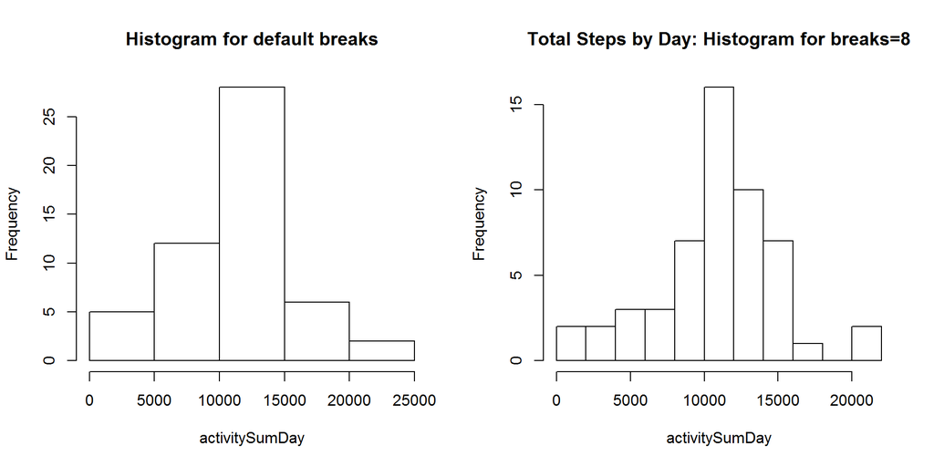

```r
activitySumDay<-tapply(activityNoNA$steps,activityNoNA$date,sum) # Although No NA is applied however the var date is a factor which preserve all the original factors of the structure.
activitySumDay<-activitySumDay[!is.na(activitySumDay)]   # eliminates the  NA because there are some complete days with NA.
par(mfrow=c(1,2))
hist(activitySumDay,main="Histogram for default breaks")
hist(activitySumDay,breaks=8, main="Total Steps by Day: Histogram for breaks=8")
```

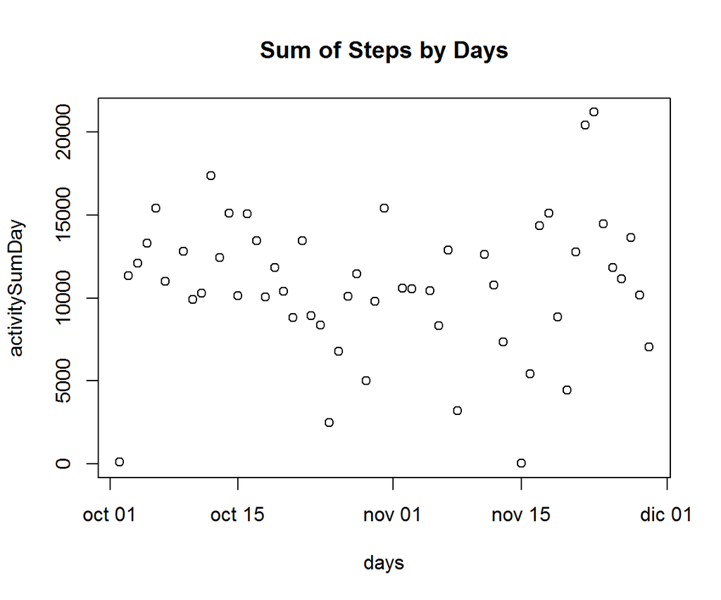

```r
par(mfrow=c(1,1))
days<-as.Date(names(activitySumDay)) # Get the x axis labes since the
plot(days,activitySumDay, main = "Sum of Steps by Days")   # Plot  the sum of steps by day
```

2. Calculate and report the **mean** and **median** and others, for the total number of steps taken per day. Using the previous defined var `activitySumDay` which store the results of mean() and fivenum() functions into a new vars to show after the results in a *table format*.

```r
fiveNames <- names(fivenum(activitySumDay)) # Get the date when the significant value occurs
fiveVal<-format(unname(fivenum(activitySumDay)),digits=5)  # Get the five significant numbers
meanActivity<-round(mean(activitySumDay),2)
```

| Parameters | minimun | 25% quantile | median | mean | 75% quantile | maximun |
| --- | --- | --- | --- | --- | --- | --- |
| value | 41 | 8841 | 10765 | 1.07661910^{4} | 13294 | 21194 |
| Date | 2012-11-15 | 2012-11-19 | 2012-11-12 | Non Aplied | 2012-10-05 | 2012-11-23 |

Notice that in the table above the mean value **10766.19** does not apply format function as this: `format(meanActivity, digist=7)`

### What is the average daily activity pattern?

1. Make a time series plot (i.e. `type = "l"`) of the 5-minute interval (x-axis) and the average number of steps taken, averaged across all days (y-axis)

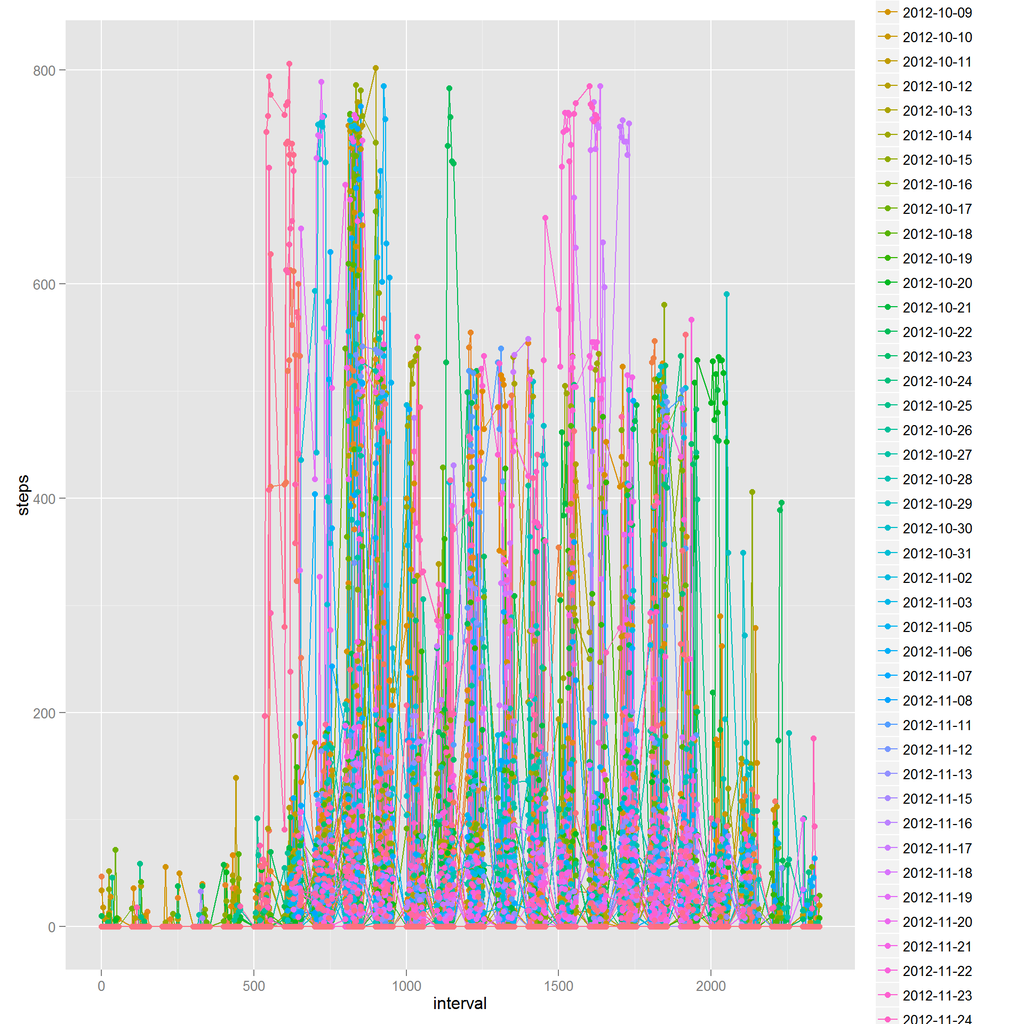

```r
library(ggplot2)
(p<-ggplot(data = activityNoNA, aes(x = interval, y = steps, colour =date)) +
  geom_line() + geom_point())
```

Instead of the standard plot the ggplot2 is used. When the parameter `fig.height=15` is adjusted that allows to see all days in the legend right side, but the figure is very tall. The next figure shows two cols for the legend. It is so difficult to convert x axis in time units Hours:minutes.

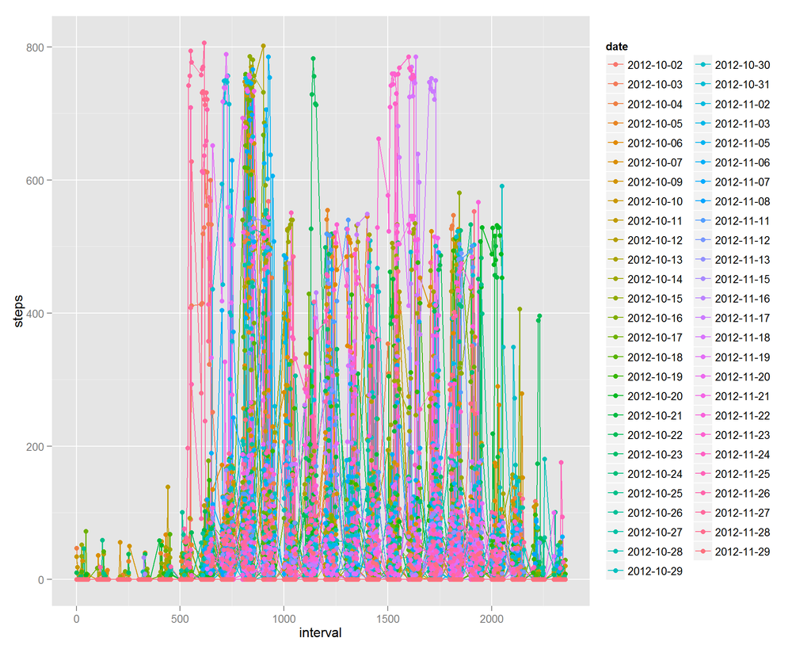

```r
(p<-ggplot(data = activityNoNA, aes(x =interval, y = steps, colour =date)) +
  geom_line() + geom_point()+ guides(col = guide_legend(ncol = 2)))
```

2. Which 5-minute interval, on average across all the days in the dataset, contains the maximum number of steps?

For this case a similar treatment as days average can be done.

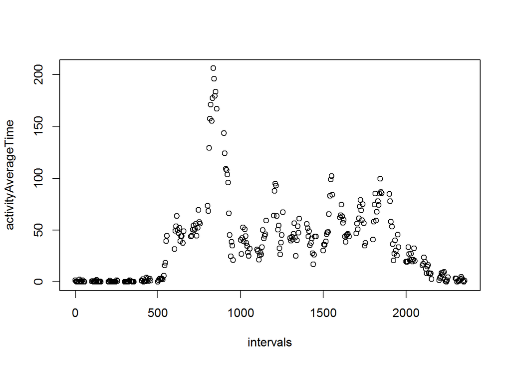

```r
activityAverageTime<-tapply(activityNoNA$steps,activityNoNA$interval,mean)
intervals<-unique(activityNoNA$interval)
plot(intervals,activityAverageTime)
```

```r
df<-data.frame(time=intervals, activity_mean<-activityAverageTime) #to make pairs
maximunIs<-df[activity_mean==max(activityAverageTime),] #get the pair which contain the maximun average
hour<- Hour_minute(maximunIs$time) #transform the decimal time to format hh:mm
```

[output not shown]

### Imputing missing values

Note that there are a number of days/intervals where there are missing values (coded as `NA`). The presence of missing days may introduce bias into some calculations or summaries of the data.

1. Calculate and report the total number of missing values in the dataset (i.e. the total number of rows with `NA`s).

See above, a new data without NA contains **2304 rows** less than original dataset. As one day corresponds 288 measures there are a total of 8 days.

2. Devise a strategy for filling in all of the missing values in the dataset. The strategy does not need to be sophisticated. For example, you could use the mean/median for that day, or the mean for that 5-minute interval, etc. The missing values elimination can be ne next strategy:
- When a complete day is recorded with NA, the day is deleted

```r
############# THE activityNoNA var (see Question 1 Histogram ) contains the data
activitySumDay<-tapply(activityNoNA$steps,activityNoNA$date,sum)
dayNA<-activitySumDay[is.na(activitySumDay)]
names(dayNA) #Show the days with no lectures, the 288 intervals contains NA
```

```
## [1] "2012-10-01" "2012-10-08" "2012-11-01" "2012-11-04" "2012-11-09"
## [6] "2012-11-10" "2012-11-14" "2012-11-30"
```

```r
daysNA<-names(dayNA)
weekdays(as.Date(daysNA)) #  empty week days, with NA
```

```
## [1] "lunes"     "lunes"     "jueves"    "domingo"   "viernes"   "sábado"
## [7] "miércoles" "viernes"
```

```r
activityNoNa2<-activityData[!activityData$date %in% daysNA,c(1,2,3)] #eliminates the data for complete days with NA. The col 4 time is not include since is not plicable the format for graphics.
nrow(activityNoNa2)
```

```
## [1] 15264
```

The number of rows in the new set is the same as if we eliminate the rows with NA in steps var, therefore this new set does not contain any day with an interval filled with NA.

3. Create a new dataset that is equal to the original dataset but with the missing data filled in.

```r
dput(activityNoNa2, file = "activity_no_NA_R.txt",
     control = c("keepNA", "keepInteger", "showAttributes"))
actity_new_data<-dget("activity_no_NA_R.txt") #maintains the same structure
str(actity_new_data)
```

```
## 'data.frame':    15264 obs. of  3 variables:
##  $ steps   : int  0 0 0 0 0 0 0 0 0 0 ...
##  $ date    : Factor w/ 61 levels "2012-10-01","2012-10-02",..: 2 2 2 2 2 2 2 2 2 2 ...
##  $ interval: int  0 5 10 15 20 25 30 35 40 45 ...
```

```r
write.table(activityNoNa2, file = "activity_no_NA_Text.txt", row.names = FALSE,sep = "\t")
NewData<-read.table(file = "activity_no_NA_Text.txt", sep = "\t")
str(NewData) #the firs row contains the name of vars it should be specified: col.names = FALSE
```

```
## 'data.frame':    15265 obs. of  3 variables:
##  $ V1: Factor w/ 618 levels "0","1","10","100",..: 618 1 1 1 1 1 1 1 1 1 ...
##  $ V2: Factor w/ 54 levels "2012-10-02","2012-10-03",..: 54 1 1 1 1 1 1 1 1 1 ...
##  $ V3: Factor w/ 289 levels "0","10","100",..: 289 1 226 2 73 136 195 198 209 212 ...
```

```r
write.csv(activityNoNa2, file = "activity_no_NA.csv",row.names = FALSE)
NewData2<-read.csv(file = "activity_no_NA.csv")
str(NewData2) #mantains the name of vars.
```

```
## 'data.frame':    15264 obs. of  3 variables:
##  $ steps   : int  0 0 0 0 0 0 0 0 0 0 ...
##  $ date    : Factor w/ 53 levels "2012-10-02","2012-10-03",..: 1 1 1 1 1 1 1 1 1 1 ...
##  $ interval: int  0 5 10 15 20 25 30 35 40 45 ...
```

The option using `write.csv` is the ideal. You can get the output activity_no_NA.csv file .

4. Make a histogram of the total number of steps taken each day and Calculate and report the **mean** and **median** total number of steps taken per day. Do these values differ from the estimates from the first part of the assignment? What is the impact of imputing missing data on the estimates of the total daily number of steps?

In this case the results are the same because no imputing is used, deleting data with NA is a better option since the number of NA to be imputing is high.

### Are there differences in activity patterns between weekdays and weekends?

For this part the `weekdays()` function may be of some help here. Use the dataset with the filled-in missing values for this part.

1. Create a new factor variable in the dataset with two levels – “weekday” and “weekend” indicating whether a given date is a weekday or weekend day.

The code to obtain the new col named `weekday_weekend`is this:

```r
NewData2$weekday<-weekdays(as.Date(NewData2$date))
weekend<-weekdays(as.Date(c("2012-10-06","2012-10-07"))) #these days are the two weekend days (independent of language used by the system: Saturday, Samedi, Sábado...)
NewData2$weekday_weekend<-ifelse(NewData2$weekday %in% weekend,"weekend","weekday")
NewData2$weekday_weekend<-as.factor(NewData2$weekday_weekend)
```

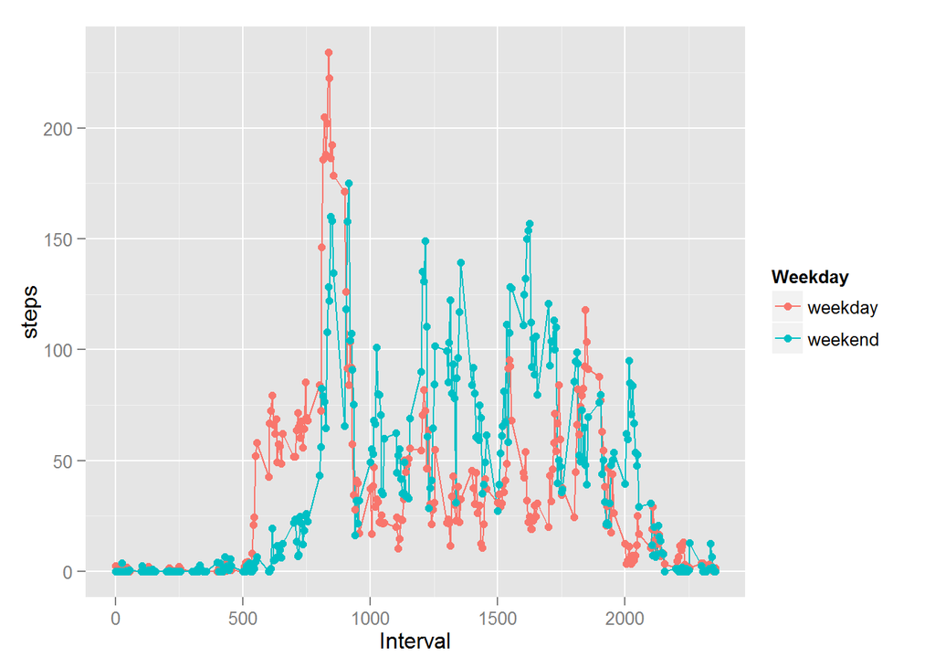

```r
activityweekday<-tapply(NewData2$steps,list(NewData2$interval,NewData2$weekday_weekend),mean)
activityweekday<-as.data.frame(as.table(activityweekday))

names(activityweekday)<-c("Interval","Weekday","steps")
activityweekday$Interval<-as.integer(levels(activityweekday$Interval))

(p<-ggplot(data = activityweekday, aes(x = Interval, y = steps, colour =Weekday)) +
   geom_line() + geom_point())
```